# Cleaning and Exploring the Olive Oil Dataset

*By Kyoosik Kim*

### Overview

> The objective of this mini project is to get familiar with the R programming. The practice includes but not limited to loading and printing data, joining data frames, and plotting data. Since the goal is more focused on practicing programming, not analyzing the data, the code snippets can be used as examples, especially for *ggplot* syntax.

### Import Libraries and Set Printing Style

```r
# printing
library(knitr)
library(kableExtra)

# manipulating data frames
library(tidyverse)
library(reshape2)

# correlation
library(corrplot)

# plotting
library(ggplot2)
library(GGally)

# plot grid
library(grid)
library(gridExtra)
library(cowplot)
```

```r
# set up printing style
print_kable <- function(df) {
  kable(df) %>%
    kable_styling(bootstrap_options = c("striped", "hover", "condensed"))
}
```

### Task 1. Read CSV Files

```r
# Load the csv files
olive_oil_chem_df <- read_csv('Data/olive_oil_chemical.csv')
print_kable(olive_oil_chem_df[1:5, ])
```

| region | c_Acidity | c_Peroxide | c_K232 | c_K270 | c_DK |
| --- | --- | --- | --- | --- | --- |
| G1 | 0.73 | 12.7 | 1.900 | 0.139 | 0.003 |
| G2 | 0.19 | 12.3 | 1.678 | 0.116 | -0.004 |
| G3 | 0.26 | 10.3 | 1.629 | 0.116 | -0.005 |
| G4 | 0.67 | 13.7 | 1.701 | 0.168 | -0.002 |
| G5 | 0.52 | 11.2 | 1.539 | 0.119 | -0.001 |

```r
olive_oil_sens_df <- read_csv('Data/olive_oil_sensory.csv')
print_kable(olive_oil_sens_df[1:5, ])
```

| region | s_yellow | s_green | s_brown | s_glossy | s_transp | s_syrup |
| --- | --- | --- | --- | --- | --- | --- |
| G1 | 21.4 | 73.4 | 10.1 | 79.7 | 75.2 | 50.3 |
| G2 | 23.4 | 66.3 | 9.8 | 77.8 | 68.7 | 51.7 |
| G3 | 32.7 | 53.5 | 8.7 | 82.3 | 83.2 | 45.4 |
| G4 | 30.2 | 58.3 | 12.2 | 81.1 | 77.1 | 47.8 |
| G5 | 51.8 | 32.5 | 8.0 | 72.4 | 65.3 | 46.5 |

### Task 2. Join Data Frames

```r
olive_combined_df <- left_join(olive_oil_chem_df, olive_oil_sens_df, by = 'region')
print_kable(olive_combined_df[1:5, ])
```

| region | c_Acidity | c_Peroxide | c_K232 | c_K270 | c_DK | s_yellow | s_green | s_brown | s_glossy | s_transp | s_syrup |
| --- | --- | --- | --- | --- | --- | --- | --- | --- | --- | --- | --- |
| G1 | 0.73 | 12.7 | 1.900 | 0.139 | 0.003 | 21.4 | 73.4 | 10.1 | 79.7 | 75.2 | 50.3 |
| G2 | 0.19 | 12.3 | 1.678 | 0.116 | -0.004 | 23.4 | 66.3 | 9.8 | 77.8 | 68.7 | 51.7 |
| G3 | 0.26 | 10.3 | 1.629 | 0.116 | -0.005 | 32.7 | 53.5 | 8.7 | 82.3 | 83.2 | 45.4 |
| G4 | 0.67 | 13.7 | 1.701 | 0.168 | -0.002 | 30.2 | 58.3 | 12.2 | 81.1 | 77.1 | 47.8 |
| G5 | 0.52 | 11.2 | 1.539 | 0.119 | -0.001 | 51.8 | 32.5 | 8.0 | 72.4 | 65.3 | 46.5 |

### Task 3. Summary of Dataset

```r
summary(olive_combined_df)
```

```
##     region            c_Acidity        c_Peroxide        c_K232
##  Length:16          Min.   :0.1500   Min.   : 8.14   Min.   :1.331
##  Class :character   1st Qu.:0.1900   1st Qu.:10.95   1st Qu.:1.536
##  Mode  :character   Median :0.2600   Median :12.40   Median :1.653
##                     Mean   :0.3119   Mean   :13.25   Mean   :1.708
##                     3rd Qu.:0.3125   3rd Qu.:15.38   3rd Qu.:1.893
##                     Max.   :0.7300   Max.   :19.40   Max.   :2.222
##      c_K270            c_DK             s_yellow        s_green
##  Min.   :0.0850   Min.   :-0.00500   Min.   :21.40   Min.   : 9.70
##  1st Qu.:0.1015   1st Qu.:-0.00325   1st Qu.:32.08   1st Qu.:12.07
##  Median :0.1160   Median :-0.00200   Median :52.80   Median :31.15
##  Mean   :0.1181   Mean   :-0.00175   Mean   :50.88   Mean   :33.51
##  3rd Qu.:0.1285   3rd Qu.: 0.00000   3rd Qu.:68.80   3rd Qu.:54.70
##  Max.   :0.1680   Max.   : 0.00300   Max.   :73.50   Max.   :73.40
##     s_brown         s_glossy        s_transp        s_syrup
##  Min.   : 8.00   Min.   :67.70   Min.   :63.50   Min.   :42.30
##  1st Qu.:10.03   1st Qu.:77.80   1st Qu.:74.17   1st Qu.:46.15
##  Median :10.80   Median :80.40   Median :77.20   Median :47.50
##  Mean   :12.33   Mean   :80.81   Mean   :78.19   Mean   :47.98
##  3rd Qu.:11.97   3rd Qu.:85.38   3rd Qu.:84.88   3rd Qu.:50.65
##  Max.   :28.40   Max.   :89.90   Max.   :89.70   Max.   :52.80
```

### Task 4. Correlation

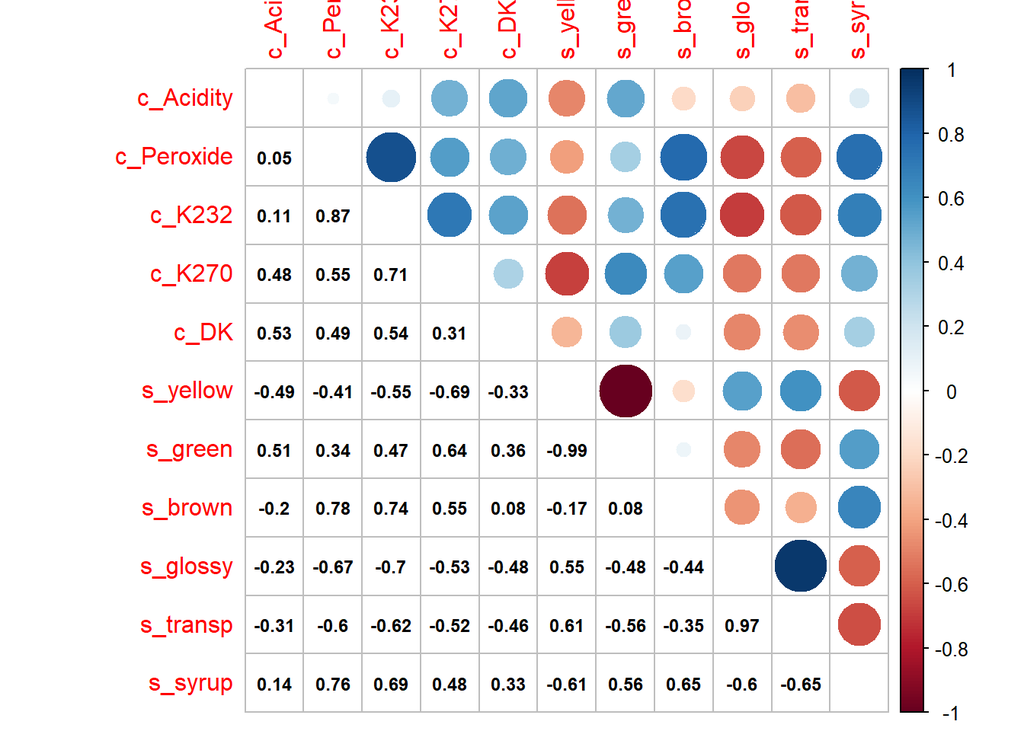

```r
olive_columns <- colnames(olive_combined_df)[-1] # drop region to get only numerical
corr <- cor(olive_combined_df[, olive_columns])
corrplot.mixed(corr, lower.col = "black", number.cex = .75, tl.pos = "lt")
```

### Task 5. Boxplot

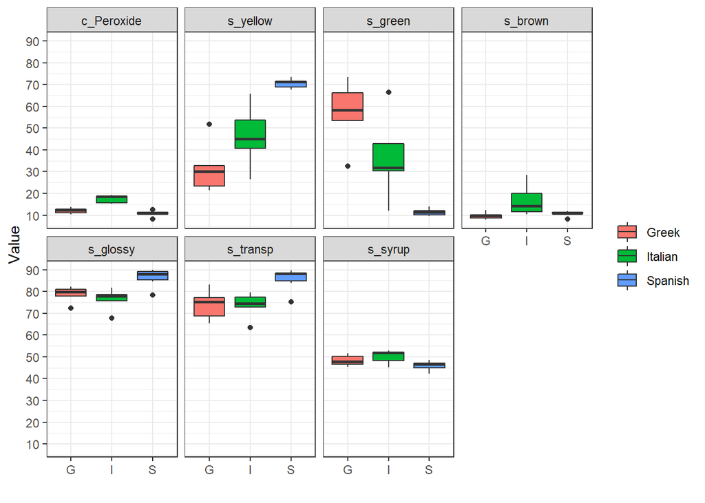

```r
olive_combined_df$group <- substr(olive_combined_df$region, 1, 1) # ex) G1, G2, ... -> G

# melt for boxplot facet
olive_boxplot1_df <- melt(data = olive_combined_df[-c(1:2, 4:6)], id = "group")
olive_boxplot2_df <- melt(data = olive_combined_df[c(2, 4:6, 13)], id = "group")

# type 's' boxplot
ggplot(olive_boxplot1_df, aes(x = group, y = value)) +
  geom_boxplot(aes(fill = group)) +
  facet_wrap(~ variable, ncol = 4) +
  labs(x = "", y = "Value", fill = "") +
  scale_y_continuous(breaks = seq(0, 100, 10)) +
  scale_fill_discrete(labels = c("Greek", "Italian", "Spanish")) +
  theme_bw()
```

#### The 7 of boxplots are variables that can be shown together ranged between 0 to 90. The values of the rest are so small as to be plotted separately as below.

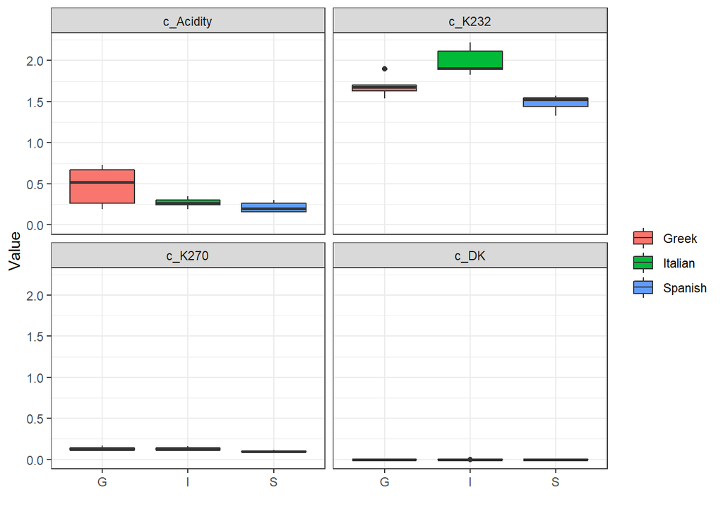

```r
ggplot(olive_boxplot2_df, aes(x = group, y = value)) +
  geom_boxplot(aes(fill = group)) +
  facet_wrap(~ variable, ncol = 2) +
  labs(x = "", y = "Value", fill = "") +
  scale_y_continuous(breaks = seq(0, 2.5, 0.5)) +
  scale_fill_discrete(labels = c("Greek", "Italian", "Spanish")) +
  theme_bw()
```

#### There are still 2 variables of which values are very small. They can be drawn with ‘plot_grid’ function of *cowplot* as followings.

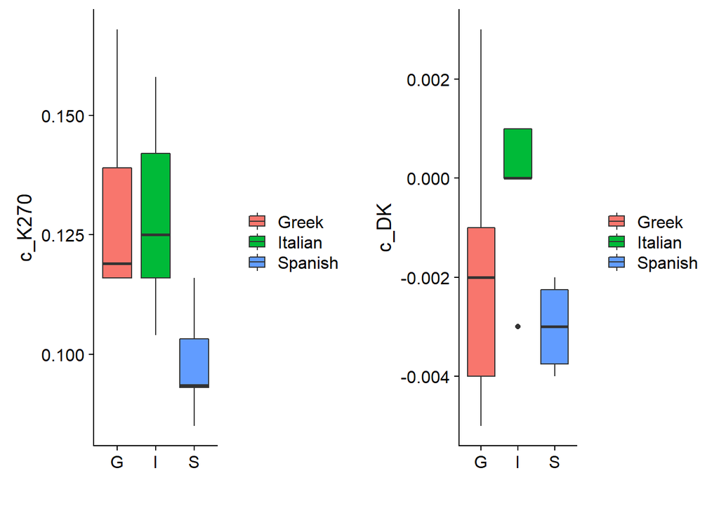

```r
plot_grid(
  ggplot(olive_combined_df, aes(x = group, y = c_K270)) +
    geom_boxplot(aes(fill = group)) + labs(x = "", fill = "") +
    scale_fill_discrete(labels = c("Greek", "Italian", "Spanish")),
  ggplot(olive_combined_df, aes(x = group, y = c_DK)) +
    geom_boxplot(aes(fill = group)) + labs(x = "", fill = "") +
    scale_fill_discrete(labels = c("Greek", "Italian", "Spanish"))
)
```

### Task 6. Pairplot

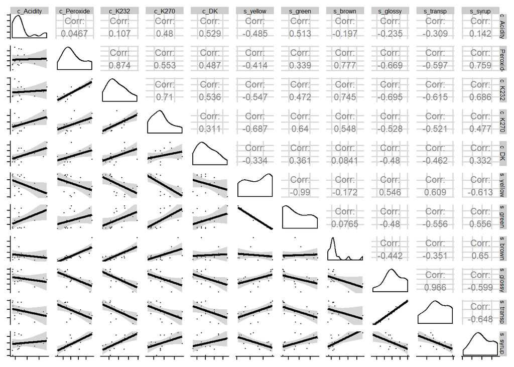

```r
ggpairs(olive_combined_df[, olive_columns],
        lower = list(continuous = wrap("smooth", size = 0.2)),
        upper = list(continuous = wrap("cor", size = 3))) +
  theme(axis.text.x = element_blank(),
        axis.text.y = element_blank(),
        strip.text.x = element_text(size = 6),
        strip.text.y = element_text(size = 6))
```

#### Some parameters are set to make the plot look better such as text size because reading texts in a complicated plot like this might be a bit challenging.

### Task 7. Histogram

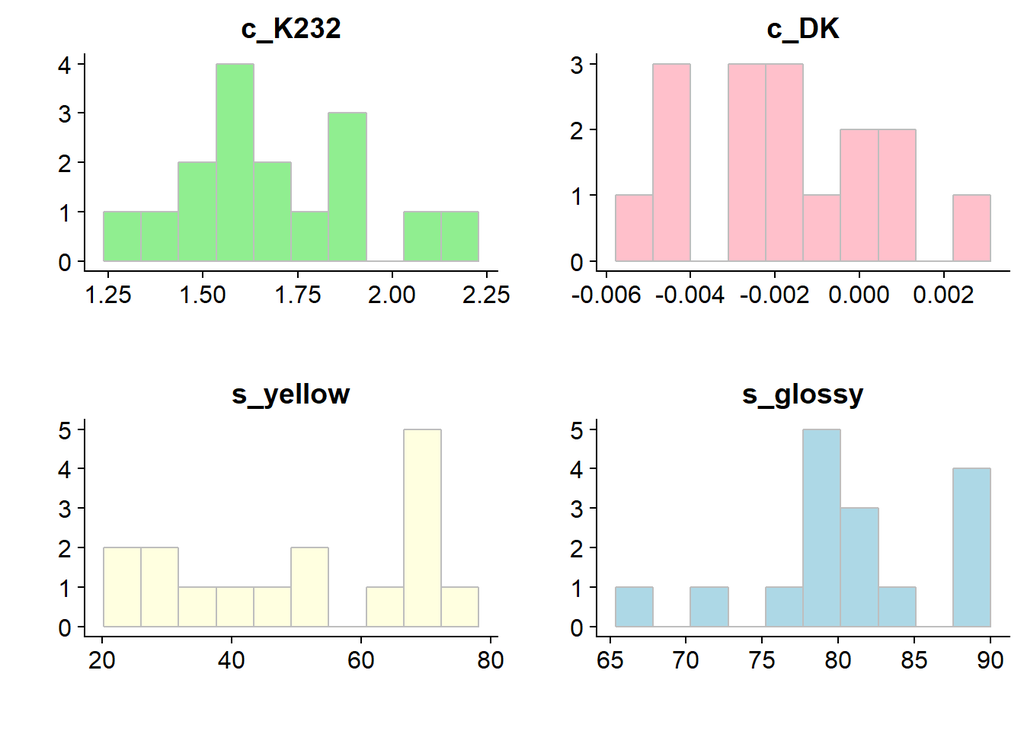

```r
hist_plot <- function(col, color) {
  p <- ggplot(olive_combined_df, aes(x = eval(parse(text = col)))) +
    geom_histogram(bins = 10, color = "gray", fill = color) +
    labs(title = col, x = "", y = "")

  return(p)
}

grid.arrange(hist_plot("c_K232", "lightgreen"),
             hist_plot("c_DK", "pink"),
             hist_plot("s_yellow", "lightyellow"),
             hist_plot("s_glossy", "lightblue"),
             ncol = 2, nrow = 2)
```

#### The 4 variables are chosen based on the result of the pairplot, the diagonal line of which is basically rough histograms for each variable.

### Task 8. Mean and Median

```r
Mean <- colMeans(olive_combined_df[, olive_columns])
Median <- apply(olive_combined_df[, olive_columns], 2, median)

stats_df <- rbind(Mean, Median)
stats_df <- data.frame(t(stats_df))
stats_df$Diff <- Mean - Median

print_kable(stats_df[1:5, ])
```

|  | Mean | Median | Diff |
| --- | --- | --- | --- |
| c_Acidity | 0.3118750 | 0.2600 | 0.0518750 |
| c_Peroxide | 13.2525000 | 12.4000 | 0.8525000 |
| c_K232 | 1.7082500 | 1.6535 | 0.0547500 |
| c_K270 | 0.1181438 | 0.1160 | 0.0021438 |
| c_DK | -0.0017500 | -0.0020 | 0.0002500 |

#### Mean and median for each column can be done in many different ways. The function ‘colMeans’ is specifically for mean values, but ‘apply’ can always be used for the same result.

### Reference

- [Tutorial for kable](https://cran.r-project.org/web/packages/kableExtra/vignettes/awesome_table_in_html.html)
- Facet for ggplot
- [Introduction to cowplot](https://cran.r-project.org/web/packages/cowplot/vignettes/introduction.html)
- [Background of ggplot](http://www.sthda.com/english/wiki/ggplot2-themes-and-background-colors-the-3-elements)
- Legend cookbook
- [Manipulating ggpair](https://stackoverflow.com/questions/28427572/manipulating-axis-titles-in-ggpairs-ggally)